# Lab12-Pregnant Smoking

April 24, 2022

Note: I need this for Mac:

```r
r = getOption("repos")
r["CRAN"] = "http://cran.us.r-project.org"
options(repos = r)
```

```r
install.packages("openintro")
library(tidyverse)
library(infer)
library(openintro)
install.packages('tidyr')
install.packages('readr')
```

```r
library(ggplot2)
library(tidyr)
library(readr)
```

Set a seed.

```r
download.file("http://www.openintro.org/stat/data/nc.RData", destfile = "ncbirths")
load("ncbirths")
ncbirths<-nc
```

1. What are the cases in this data set? How many cases are there in our sample? The cases in this data set are data on individual births recorded in NC. There are 1000 cases.

1.1. Make summaries of the variables in your dataset, determine which variables are categorical and which are numerical. fage numerical mage numerical mature categorical weeks numerical premie categorical visits numerical marital categorical gained numerical weight numerical lowbirthweight categorical gender categorical habit categorical whitemom categorical

-The actual data (integer, factor, numeric) types of your data:

```r
str(ncbirths)
```

```
## 'data.frame':    1000 obs. of  13 variables:
##  $ fage          : int  NA NA 19 21 NA NA 18 17 NA 20 ...
##  $ mage          : int  13 14 15 15 15 15 15 15 16 16 ...
##  $ mature        : Factor w/ 2 levels "mature mom","younger mom": 2 2 2 2 2 2 2 2 2 2 ...
##  $ weeks         : int  39 42 37 41 39 38 37 35 38 37 ...
##  $ premie        : Factor w/ 2 levels "full term","premie": 1 1 1 1 1 1 1 2 1 1 ...
##  $ visits        : int  10 15 11 6 9 19 12 5 9 13 ...
##  $ marital       : Factor w/ 2 levels "married","not married": 1 1 1 1 1 1 1 1 1 1 ...
##  $ gained        : int  38 20 38 34 27 22 76 15 NA 52 ...
##  $ weight        : num  7.63 7.88 6.63 8 6.38 5.38 8.44 4.69 8.81 6.94 ...
##  $ lowbirthweight: Factor w/ 2 levels "low","not low": 2 2 2 2 2 1 2 1 2 2 ...
##  $ gender        : Factor w/ 2 levels "female","male": 2 2 1 2 1 2 2 2 2 1 ...
##  $ habit         : Factor w/ 2 levels "nonsmoker","smoker": 1 1 1 1 1 1 1 1 1 1 ...
##  $ whitemom      : Factor w/ 2 levels "not white","white": 1 1 2 2 1 1 1 1 2 2 ...
```

1.2. For numerical variables, are there outliers? There are incredible outliers for each of these variables. For intance, in this data set, two babies were born weighing one pound.

-Amount (actual data value) and frequency (number of times that value occurs) of each variable:

```r
table(ncbirths$fage)
```

```
##
## 14 16 17 18 19 20 21 22 23 24 25 26 27 28 29 30 31 32 33 34 35 36 37 38 39 40
##  1  1  4 11  9 26 40 35 27 37 36 37 34 47 31 49 43 47 45 52 48 28 25 26 14 15
## 41 42 43 44 45 46 47 48 50 53 55
## 11 16  7  7  7  4  3  3  1  1  1
```

```r
table(ncbirths$mage)
```

```
##
## 13 14 15 16 17 18 19 20 21 22 23 24 25 26 27 28 29 30 31 32 33 34 35 36 37 38
##  1  1  6 10 19 38 35 66 51 60 51 53 54 51 47 53 52 39 52 38 45 45 35 31 26 12
## 39 40 41 42 45 46 50
##  7  9  8  2  1  1  1
```

```r
table(ncbirths$weeks)
```

```
##
##  20  22  24  25  26  28  29  30  31  32  33  34  35  36  37  38  39  40  41  42
##   1   3   2   3   4   3   5   4   6   8  16  19  32  46 105 178 237 168  99  25
##  43  44  45
##  17  13   4
```

```r
table(ncbirths$visits)
```

```
##
##   0   2   3   4   5   6   7   8   9  10  11  12  13  14  15  16  17  18  19  20
##   7   5   8  12  30  26  17  49  39 132  75 143  78 100 139  47  16  34   4  18
##  22  23  24  25  26  30
##   3   1   1   1   1   5
```

```r
table(ncbirths$gained)
```

```
##
##  0  1  2  3  4  5  6  7  8  9 10 11 12 13 14 15 16 17 18 19 20 21 22 23 24 25
## 28  3  3  3  1  2  2  2  2  3 20  4 10 15  9 22  7  9 19 11 74 12 21 29 17 57
## 26 27 28 29 30 31 32 33 34 35 36 37 38 39 40 41 42 43 44 45 46 47 48 50 51 52
## 13 20 24 20 86 15 19 14 19 68 16 14 22  7 55 10  6  8  8 20  4 11  6 28  2  4
## 53 54 55 56 57 58 59 60 61 62 65 68 70 72 75 76 77 80 85
##  1  3 14  6  3  5  1 12  2  2  4  2  5  2  2  1  1  1  2
```

```r
table(ncbirths$weight)
```

```
##
##     1  1.19  1.31  1.38  1.44   1.5  1.56  1.63  1.69  1.88  2.19  2.25   2.5
##     2     1     1     3     2     2     1     1     2     1     1     2     1
##  2.63  2.69  2.88  2.94     3  3.19  3.25  3.31  3.44  3.56  3.63  3.75  3.81
##     1     2     3     1     1     1     1     1     1     1     2     2     1
##  3.94     4  4.06  4.13  4.19  4.25  4.31  4.44   4.5  4.56  4.63  4.69  4.75
##     2     2     2     2     1     1     1     3     3     4     2     4     6
##  4.88  4.94     5  5.06  5.13  5.19  5.25  5.38  5.44   5.5  5.56  5.63  5.69
##     1     2     4     3     2     2     4     8     7     7     5     8     4
##  5.75  5.81  5.88  5.94     6  6.06  6.13  6.19  6.25  6.31  6.38  6.44   6.5
##     4     9    12    15    15    10     6    11    16    15    16     8    15
##  6.56  6.63  6.69  6.75  6.81  6.88  6.94     7  7.06  7.13  7.19  7.25  7.31
##    13     9    13    23    12    25    14    22    20    24    21    22    24
##  7.38  7.44   7.5  7.56  7.63  7.69  7.75  7.81  7.88  7.94     8  8.06  8.13
##    21    30    24    19    18    17    17    20    25    16    19    13    17
##  8.19  8.25  8.31  8.38  8.44   8.5  8.56  8.63  8.69  8.75  8.81  8.88  8.94
##    17    16    12    20    14    15    11     5     4    14    12     9     4
##     9  9.06  9.13  9.19  9.25  9.31  9.38   9.5  9.56  9.63  9.69  9.75  9.81
##     8     6     7     7     6     5     2     4     3     3     1     2     1
##  9.88  9.94 10.06 10.13 10.19 10.25 10.38 11.63 11.75
##     4     1     2     2     1     1     1     1     1
```

3. Create a filtered data frame called ncbirths_white that contain data only from white mothers.

```r
ncbirths_white<-filter(ncbirths, whitemom == "white")
```

3.1. Calculate the mean of the weights of their babies. 7.25 pounds is the mean weight

```r
summary(ncbirths_white)
```

```
##       fage            mage               mature        weeks
##  Min.   :14.00   Min.   :15.00   mature mom :103   Min.   :22.00
##  1st Qu.:26.00   1st Qu.:23.00   younger mom:611   1st Qu.:38.00
##  Median :31.00   Median :27.50                     Median :39.00
##  Mean   :30.69   Mean   :27.65                     Mean   :38.51
##  3rd Qu.:35.00   3rd Qu.:32.00                     3rd Qu.:40.00
##  Max.   :50.00   Max.   :50.00                     Max.   :45.00
##  NA's   :77                                        NA's   :2
##        premie        visits            marital        gained
##  full term:616   Min.   : 0.0   married    :203   Min.   : 0.00
##  premie   : 96   1st Qu.:10.0   not married:510   1st Qu.:22.00
##  NA's     :  2   Median :12.0   NA's       :  1   Median :30.00
##                  Mean   :12.3                     Mean   :30.98
##                  3rd Qu.:15.0                     3rd Qu.:40.00
##                  Max.   :30.0                     Max.   :85.00
##                  NA's   :4                        NA's   :20
##      weight      lowbirthweight    gender          habit          whitemom
##  Min.   : 1.00   low    : 68    female:367   nonsmoker:617   not white:  0
##  1st Qu.: 6.63   not low:646    male  :347   smoker   : 96   white    :714
##  Median : 7.44                               NA's     :  1
##  Mean   : 7.25
##  3rd Qu.: 8.13
##  Max.   :11.75
##
```

```r
inference(y = ncbirths$weight, x = ncbirths$habit, est = "mean", type = "ht", null = 0,
          alternative = "twosided", method = "theoretical")
```

```
## Response variable: numerical, Explanatory variable: categorical
## Difference between two means
## Summary statistics:
## n_nonsmoker = 873, mean_nonsmoker = 7.1443, sd_nonsmoker = 1.5187
## n_smoker = 126, mean_smoker = 6.8287, sd_smoker = 1.3862
```

```
## Observed difference between means (nonsmoker-smoker) = 0.3155
##
## H0: mu_nonsmoker - mu_smoker = 0
## HA: mu_nonsmoker - mu_smoker != 0
## Standard error = 0.134
## Test statistic: Z =  2.359
## p-value =  0.0184
```

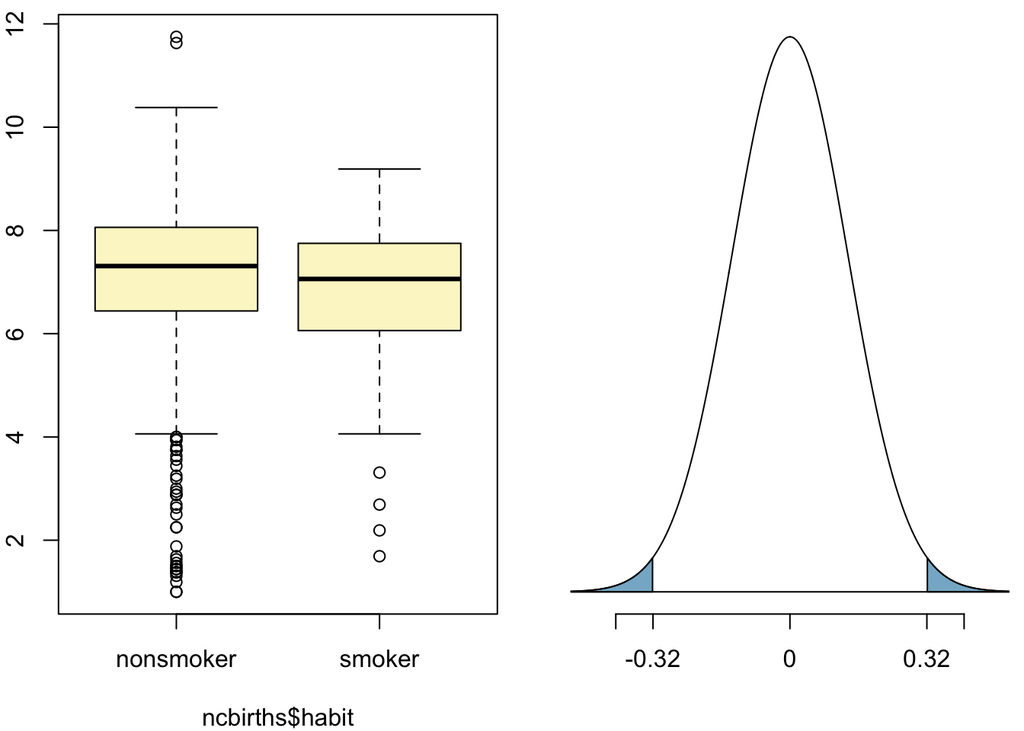

5.1. Visualize the null distribution.

```r
inference(y = ncbirths$weight, x = ncbirths$habit, est = "mean", type = "ci", null = 0,
          alternative = "twosided", method = "theoretical",
          order = c("smoker","nonsmoker"))
```

```
## Response variable: numerical, Explanatory variable: categorical
## Difference between two means
## Summary statistics:
## n_smoker = 126, mean_smoker = 6.8287, sd_smoker = 1.3862
## n_nonsmoker = 873, mean_nonsmoker = 7.1443, sd_nonsmoker = 1.5187
```

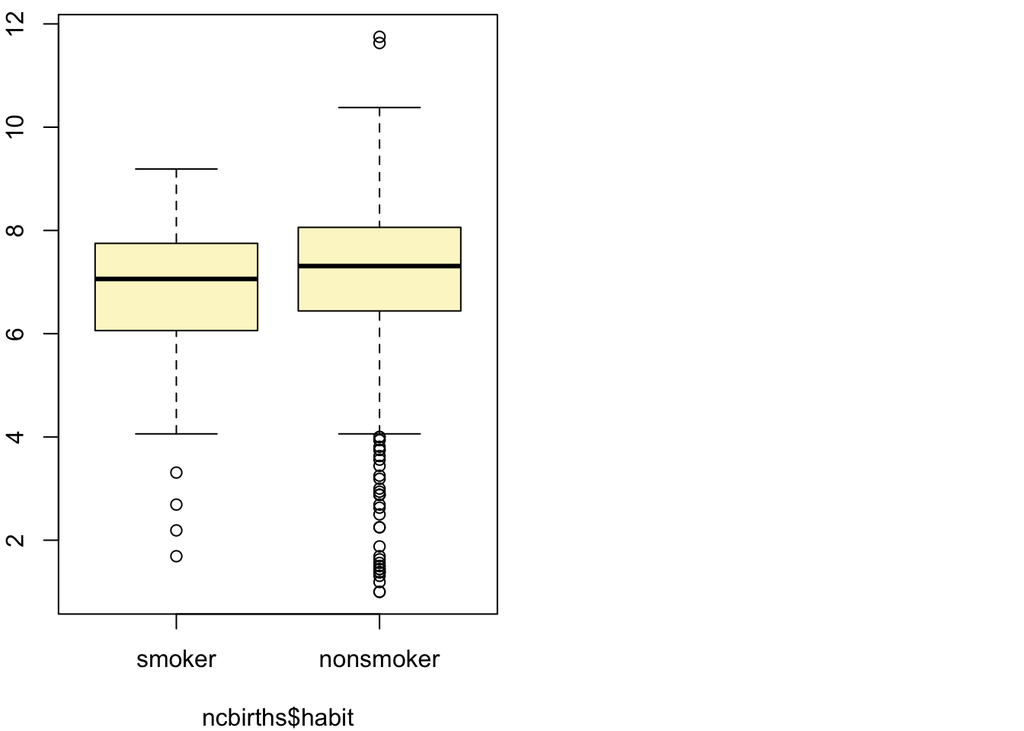

```
## Observed difference between means (smoker-nonsmoker) = -0.3155
##
## Standard error = 0.1338
## 95 % Confidence interval = ( -0.5777 , -0.0534 )
```

5.2. Calculate the p-value. p-value = 0.0184

5.3. Interpret the results in context of the data and the hypothesis test. There is a mean difference in average birth weight when comparing smokers versus non-smokers.

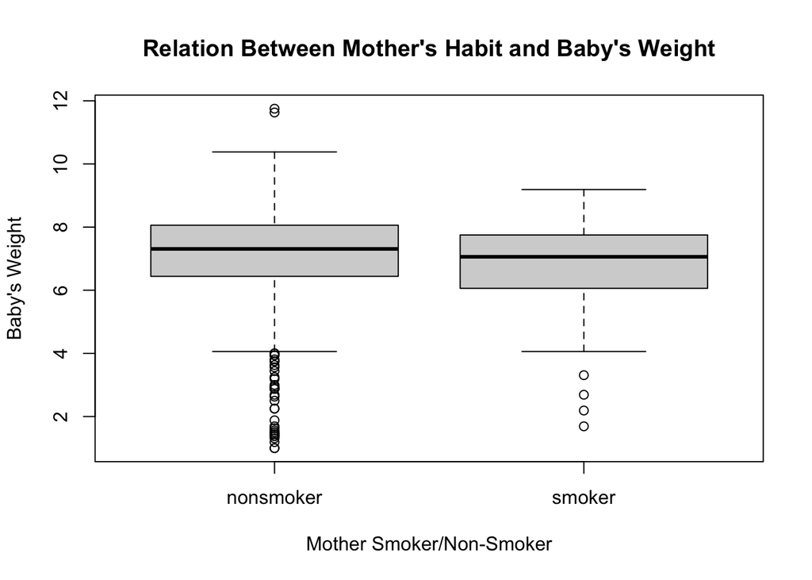

```r
boxplot(weight~habit,data=ncbirths, main="Relation Between Mother's Habit and Baby's Weight",
    ylab="Baby's Weight", xlab="Mother Smoker/Non-Smoker")
```

6.1. What does the plot highlight about the relationship between these two variables? Mothers who smoke have babies of lower weight than mothers who do not smoke.

7. Before moving forward, save a version of the dataset omitting observations where there are NAs for habit. You can call this version ncbirths_habitgiven.

```r
ncbirths_habitgiven<- na.omit(ncbirths)
```

```r
ncbirths_habitgiven %>%
  group_by(habit) %>%
  summarise(mean_weight = mean(weight))
```

```
## # A tibble: 2 × 2
##   habit     mean_weight
##   <fct>           <dbl>
## 1 nonsmoker        7.25
## 2 smoker           6.89
```

8. Write the hypotheses for testing if the average weights of babies born to smoking and non-smoking mothers are different. Null hypothesis: There is no difference in average pounds weight of babies born to smoking mothers versus babies borth to non-smoking mothers.
9. Are the conditions necessary for conducting simulation based inference satisfied? Explain your reasoning. Yes, the conditions necessary are met. After doing a bit of research, I discovered this answer at: https://rpubs.com/millerfe17/MillerHW5.

```r
by(ncbirths$weight, ncbirths$habit, length)
```

```
## ncbirths$habit: nonsmoker
## [1] 873
## ------------------------------------------------------------
## ncbirths$habit: smoker
## [1] 126
```

10. Run the appropriate hypothesis test, calculate the p-value, and interpret the results in context of the data and the hypothesis test.

```r
inference(y = ncbirths$weight, x = ncbirths$habit, est = "mean", type = "ht", null = 0, alternative = "twosided", method = "theoretical")
```

```
## Response variable: numerical, Explanatory variable: categorical
## Difference between two means
## Summary statistics:
## n_nonsmoker = 873, mean_nonsmoker = 7.1443, sd_nonsmoker = 1.5187
## n_smoker = 126, mean_smoker = 6.8287, sd_smoker = 1.3862
```

```
## Observed difference between means (nonsmoker-smoker) = 0.3155
##
## H0: mu_nonsmoker - mu_smoker = 0
## HA: mu_nonsmoker - mu_smoker != 0
## Standard error = 0.134
## Test statistic: Z =  2.359
## p-value =  0.0184
```

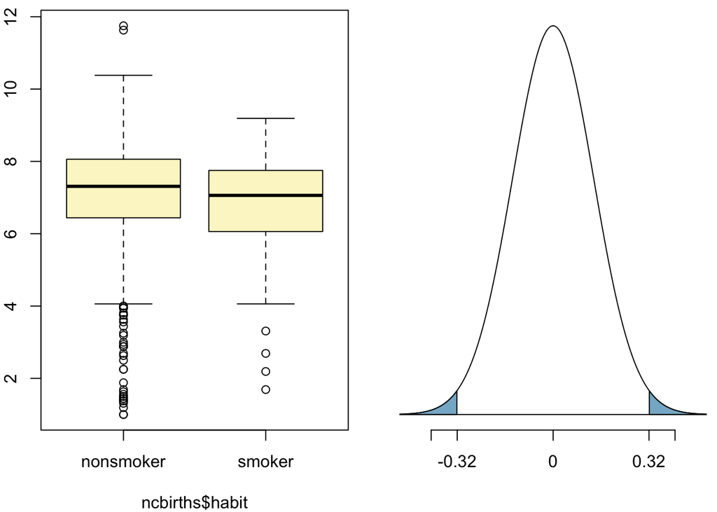

11. Construct a 95% confidence interval for the difference between the average weights of babies born to smoking and non-smoking mothers.

```r
inference(y = nc$weight, x = nc$habit, est = "mean", type = "ci", null = 0,
          alternative = "twosided", method = "theoretical",
          order = c("smoker","nonsmoker"))
```

```
## Response variable: numerical, Explanatory variable: categorical
## Difference between two means
## Summary statistics:
## n_smoker = 126, mean_smoker = 6.8287, sd_smoker = 1.3862
## n_nonsmoker = 873, mean_nonsmoker = 7.1443, sd_nonsmoker = 1.5187
```

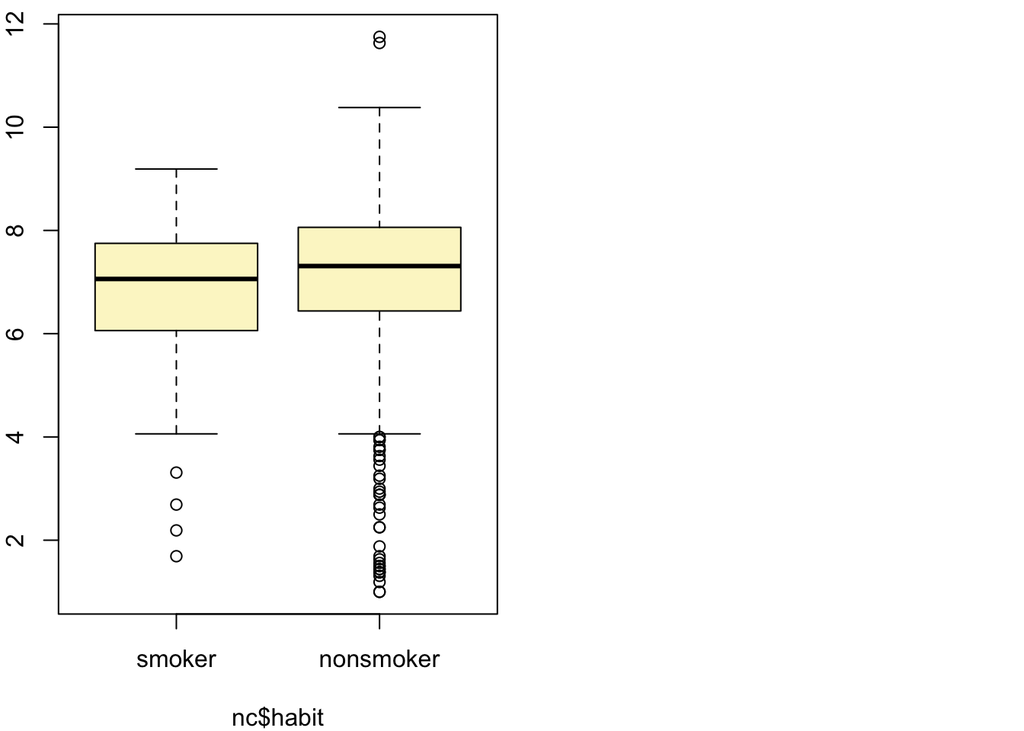

```
## Observed difference between means (smoker-nonsmoker) = -0.3155
##
## Standard error = 0.1338
## 95 % Confidence interval = ( -0.5777 , -0.0534 )
```

Baby weight vs. mother’s age

Focus on two variables: maturemom, lowbirthweight.

12. First, a non-inference task: Determine the age cutoff for younger and mature mothers. Use a method of your choice, and explain how your method works. I determined that the minimum age of a mature mom is 35. Thus, younger mothers are those aged from the youngest in our sample up to 34.

```r
library(dplyr)
ncbirths %>% group_by(mature) %>% summarize(min(mage))
```

```
## # A tibble: 2 × 2
##   mature      `min(mage)`
##   <fct>             <int>
## 1 mature mom           35
## 2 younger mom          13
```

The other variable of interest is lowbirthweight.

13. Conduct a hypothesis test evaluating whether the proportion of low birth weight babies is higher for mature mothers. State the hypotheses, verify the conditions, run the test and calculate the p-value, and state your conclusion in context of the research question. Use α=0.05

Null hypothesis: There is no difference in average weight of babies between mature mothers and non-mature mothers. p-value = 0.8526

```r
inference(y = ncbirths$weight, x = ncbirths$mature, est = "mean", type = "ht", null = 0,
          alternative = "twosided", method = "theoretical")
```

```
## Response variable: numerical, Explanatory variable: categorical
## Difference between two means
## Summary statistics:
## n_mature mom = 133, mean_mature mom = 7.1256, sd_mature mom = 1.6591
## n_younger mom = 867, mean_younger mom = 7.0972, sd_younger mom = 1.4855
```

```
## Observed difference between means (mature mom-younger mom) = 0.0283
##
## H0: mu_mature mom - mu_younger mom = 0
## HA: mu_mature mom - mu_younger mom != 0
## Standard error = 0.152
## Test statistic: Z =  0.186
## p-value =  0.8526
```

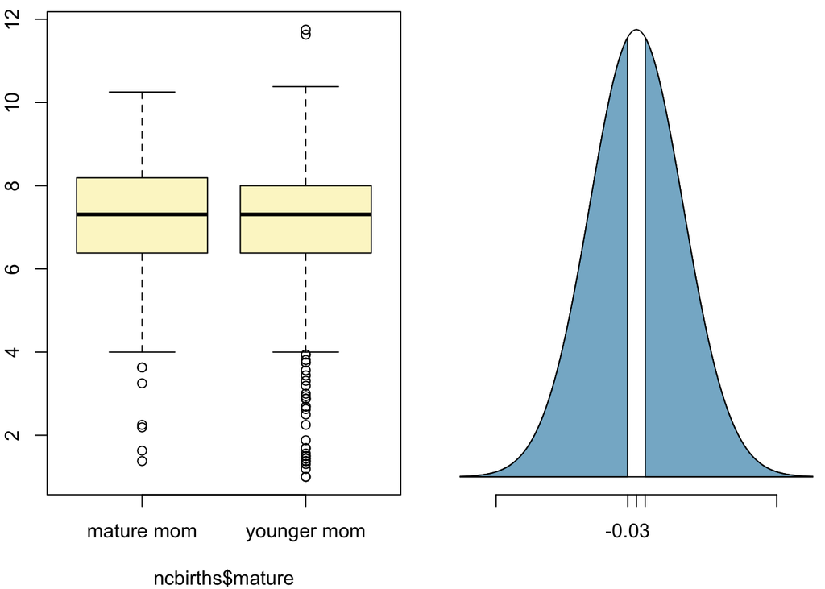

13.1. If you find a significant difference, construct a confidence interval, at the equivalent level to the hypothesis test, for the difference between the proportions of low birth weight babies between mature and younger moms, and interpret this interval in context of the data.

```r
inference(y = ncbirths$weight, x = ncbirths$mature, est = "mean", type = "ci", null = 0,
          alternative = "twosided", method = "theoretical")
```

```
## Response variable: numerical, Explanatory variable: categorical
## Difference between two means
## Summary statistics:
## n_mature mom = 133, mean_mature mom = 7.1256, sd_mature mom = 1.6591
## n_younger mom = 867, mean_younger mom = 7.0972, sd_younger mom = 1.4855
```

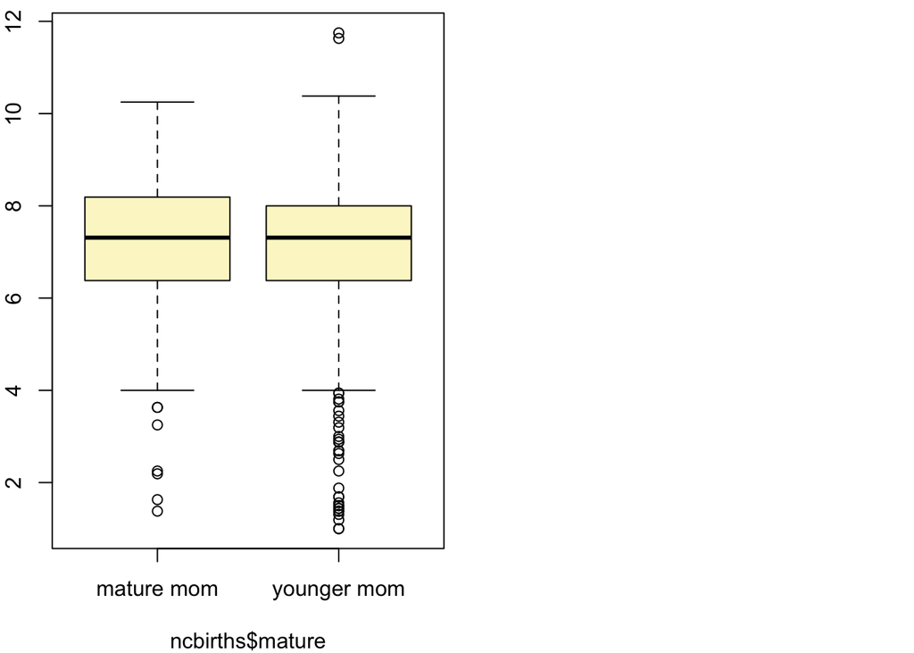

```
## Observed difference between means (mature mom-younger mom) = 0.0283
##
## Standard error = 0.1525
## 95 % Confidence interval = ( -0.2705 , 0.3271 )
```